# index

## Effect of COVID-19 and other world events on 20 tech stocks

COVID-19 has changed our lives. We are in lockdown, and have had to make major changes to our lifestyles. The stock market has had to deal with some drastic changes of its own. In this project I will explore the fate of some of tech stocks to see how good (or bad) they have braved the COVID-19 storm.

Disclaimer: this project is meant for some basic pandas and viz skills practice and **should not** be used to derive any financial advice.

```
Last updated: 2024-04-04 at 11:03:07
```

### Get the Data

In this section I use pandas to scrape data from Yahoo! finance using pandas.

#### Using pd.concat to concatenate the stock dataframes together to a single data frame called tech_stocks

| Stock Ticker Stock Info Date | MSFT Open | MSFT High | MSFT Low | MSFT Close | MSFT Adj Close | MSFT Volume | AAPL Open | AAPL High | AAPL Low | AAPL Close | ... | DBX Low | DBX Close | DBX Adj Close | DBX Volume | ADBE Open | ADBE High | ADBE Low | ADBE Close | ADBE Adj Close | ADBE Volume |
| --- | --- | --- | --- | --- | --- | --- | --- | --- | --- | --- | --- | --- | --- | --- | --- | --- | --- | --- | --- | --- | --- |
| 2024-03-27 | 424.440002 | 424.450012 | 419.010010 | 421.429993 | 421.429993 | 16705000 | 170.410004 | 173.600006 | 170.110001 | 173.309998 | ... | 24.184999 | 24.440001 | 24.440001 | 3753800 | 515.469971 | 516.859985 | 499.700012 | 504.399994 | 504.399994 | 4228400 |
| 2024-03-28 | 420.959991 | 421.869995 | 419.119995 | 420.720001 | 420.720001 | 21871200 | 171.750000 | 172.229996 | 170.509995 | 171.479996 | ... | 24.080000 | 24.299999 | 24.299999 | 3309600 | 508.119995 | 509.000000 | 500.260010 | 504.600006 | 504.600006 | 3897000 |
| 2024-04-01 | 423.950012 | 427.890015 | 422.220001 | 424.570007 | 424.570007 | 16316000 | 171.190002 | 171.250000 | 169.479996 | 170.029999 | ... | 24.170000 | 24.309999 | 24.309999 | 2504300 | 504.989990 | 506.920013 | 499.309998 | 502.089996 | 502.089996 | 2056000 |
| 2024-04-02 | 420.109985 | 422.380005 | 417.839996 | 421.440002 | 421.440002 | 17912000 | 169.080002 | 169.339996 | 168.229996 | 168.839996 | ... | 23.809999 | 23.900000 | 23.900000 | 3010800 | 494.399994 | 500.750000 | 491.339996 | 499.209991 | 499.209991 | 3083300 |
| 2024-04-03 | 419.730011 | 423.260010 | 419.089996 | 420.450012 | 420.450012 | 16475600 | 168.789993 | 170.679993 | 168.580002 | 169.649994 | ... | 23.469999 | 23.480000 | 23.480000 | 3118100 | 497.359985 | 498.859985 | 494.709991 | 497.010010 | 497.010010 | 2601900 |

5 rows × 120 columns

What is the maximum and minimum of the Close price for each tech company's stock throughout the time period? Let's also use a bar plot to visualize the data as well.

Note: We use a log scale for close price to normalize the values to a uniform scale.

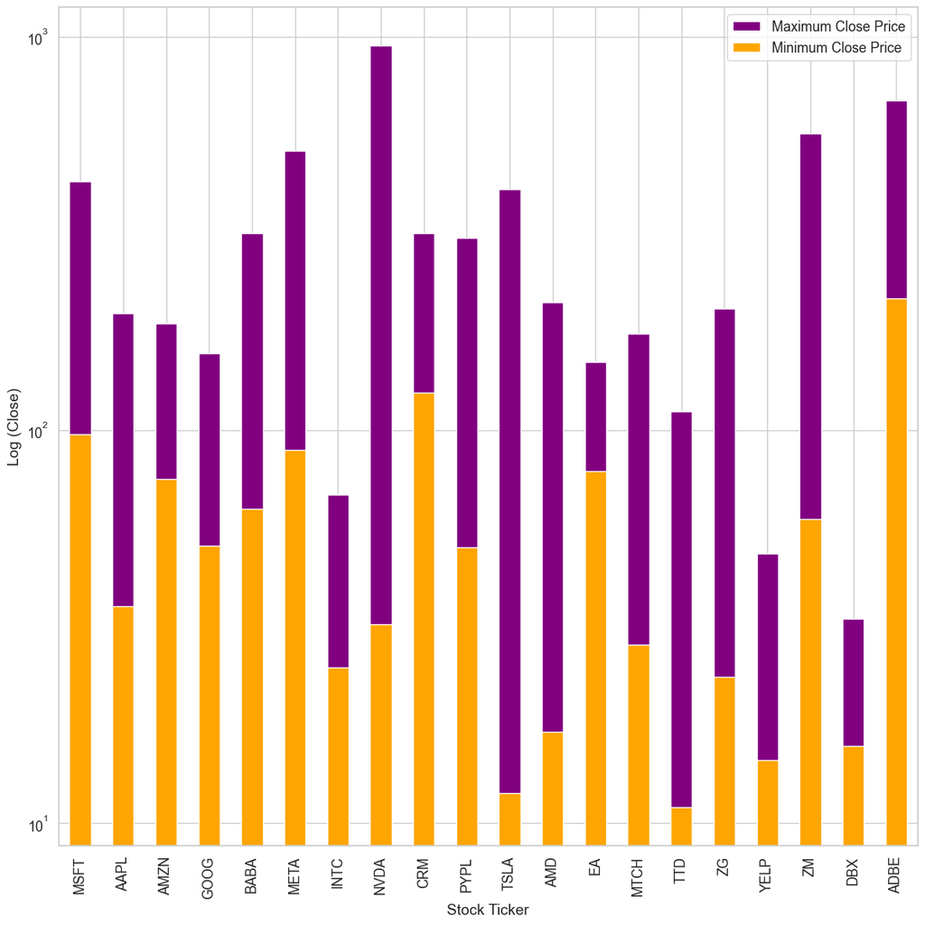

Using the bar-plot above, stocks can be classified into two broad groups: Reliable stocks and Volatile stocks.

**Reliable stocks** are the ones that didnot show much difference between the minimum Close price and maximum Close Price in the time period specified. e.g.: GOOG and AMZN. **Volatile stocks** are the ones that fluctate the most between the minimum and maximum closing price of stocks. e.g.: TTD and TSLA

However, a more interesting comparison is to compare the same data against two separate time-periods: Pre-COVID-19 and Post-COVID-19.

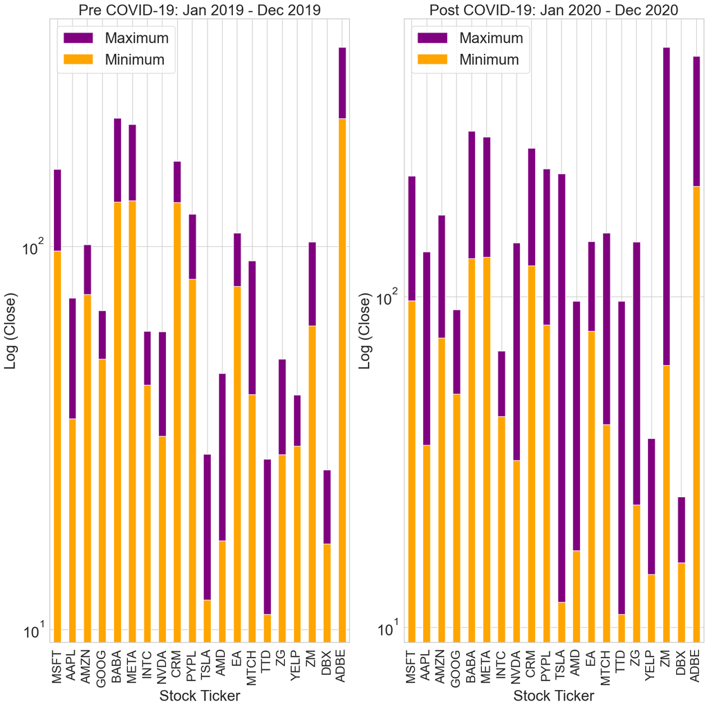

It is clear that the more **Reliable** stocks like AAPL and AMZN in the pre COVID-19 period saw significant volatility in their closing prices once the COVID-19 storm hit.

The next analysis is to use pandas pct_change() method on the Close column to create a **Returns** value. A return is defined as the change in price of stocks over time, which may be represented in terms of price change or percentage change. A positive return represents a profit while a negative return marks a loss.

| Date | MSFT Return | AAPL Return | AMZN Return | GOOG Return | BABA Return | META Return | INTC Return | NVDA Return | CRM Return | PYPL Return | TSLA Return | AMD Return | EA Return | MTCH Return | TTD Return | ZG Return | YELP Return | ZM Return | DBX Return | ADBE Return |
| --- | --- | --- | --- | --- | --- | --- | --- | --- | --- | --- | --- | --- | --- | --- | --- | --- | --- | --- | --- | --- |
| 2024-03-27 | -0.000522 | 0.021213 | 0.008581 | 0.001582 | 0.001539 | -0.004094 | 0.042391 | -0.024967 | -0.014551 | -0.001500 | 0.012157 | 0.009670 | 0.007410 | 0.005887 | 0.001838 | 0.031179 | 0.022222 | 0.004069 | -0.000409 | -0.006304 |
| 2024-03-28 | -0.001685 | -0.010559 | 0.003058 | 0.002106 | 0.010756 | -0.016766 | 0.009139 | 0.001175 | -0.000664 | 0.006309 | -0.022466 | 0.005011 | 0.006067 | 0.011148 | 0.002408 | -0.035275 | 0.007673 | -0.018763 | -0.005728 | 0.000397 |
| 2024-04-01 | 0.009151 | -0.008456 | 0.003271 | 0.027847 | 0.013958 | 0.011883 | 0.007924 | 0.000077 | 0.003586 | -0.029258 | -0.003242 | 0.015790 | 0.005050 | -0.010198 | -0.001258 | -0.009611 | 0.006853 | -0.009790 | 0.000412 | -0.004974 |
| 2024-04-02 | -0.007372 | -0.006999 | -0.001547 | -0.004026 | -0.006679 | 0.012252 | -0.013028 | -0.010082 | 0.005757 | -0.005690 | -0.049024 | -0.025308 | -0.008925 | -0.019215 | -0.002520 | -0.034810 | 0.006554 | -0.014676 | -0.016865 | -0.005736 |
| 2024-04-03 | -0.002349 | 0.004797 | 0.009519 | 0.003208 | -0.006037 | 0.018839 | -0.082157 | -0.005455 | 0.002434 | 0.010516 | 0.010502 | 0.011584 | 0.002800 | 0.015616 | -0.001722 | 0.002186 | 0.025044 | -0.008780 | -0.017573 | -0.004407 |

A looks at the minimum and maximum returns for each stock tick in this time-period:

```
MSFT Return   2020-03-16
AAPL Return   2020-03-16
AMZN Return   2022-04-29
GOOG Return   2020-03-16
BABA Return   2020-12-24
META Return   2022-02-03
INTC Return   2020-03-16
NVDA Return   2020-03-16
CRM Return    2020-03-16
PYPL Return   2022-02-02
TSLA Return   2020-09-08
AMD Return    2020-03-12
EA Return     2019-02-06
MTCH Return   2022-08-03
TTD Return    2021-05-10
ZG Return     2020-03-16
YELP Return   2020-03-16
ZM Return     2020-11-09
DBX Return    2024-02-16
ADBE Return   2022-09-15
dtype: datetime64[ns]
```

```
MSFT Return   2020-03-13
AAPL Return   2020-03-13
AMZN Return   2022-02-04
GOOG Return   2019-07-26
BABA Return   2022-03-16
META Return   2023-02-02
INTC Return   2020-03-13
NVDA Return   2023-05-25
CRM Return    2020-08-26
PYPL Return   2020-03-24
TSLA Return   2020-02-03
AMD Return    2019-01-30
EA Return     2019-02-08
MTCH Return   2019-08-07
TTD Return    2022-08-10
ZG Return     2019-02-22
YELP Return   2020-04-29
ZM Return     2020-09-01
DBX Return    2020-02-21
ADBE Return   2020-03-13
dtype: datetime64[ns]
```

And for some, their highest returns were seen in March 2020 as well thereby confirming that the COVID-19 has indeed rendered the stock market more unpredictable than in the recent past.

Now, two new series, named `pre_corona` and `post_corona` are initialised with the standard deviation of stock returns from October - December 2019 and standard deviation of stock returns from January - March 2020, respectively. This series is sorted and hence if the stocks occur at the right end of the chart, they are deemed **volatile** with significant values of standard deviation whereas if they occur on the left they could be deemed **reliable**.

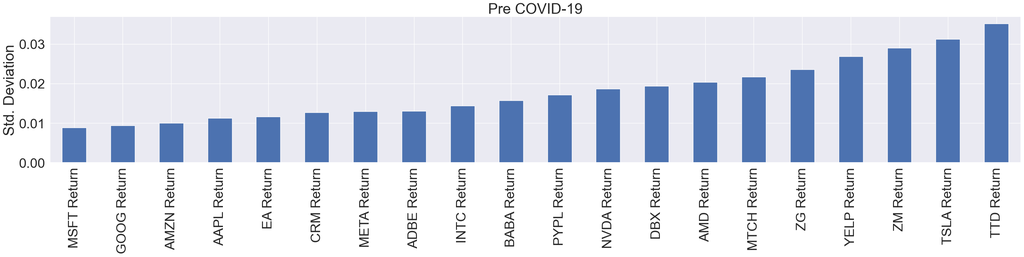

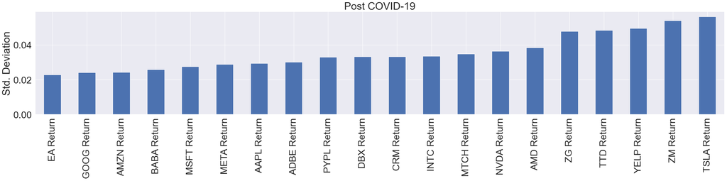

From the above collection, let's choose 5 stocks that have suffered significant effects. I am picking the following - MSFT, BABA, AAPL, MTCH and ZM. Interesting is the irregularity of ZM stocks (that provides a video conferencing service) which shot up to being a necessary tool for all kinds of Work from Home requirements.

[interactive chart not shown]

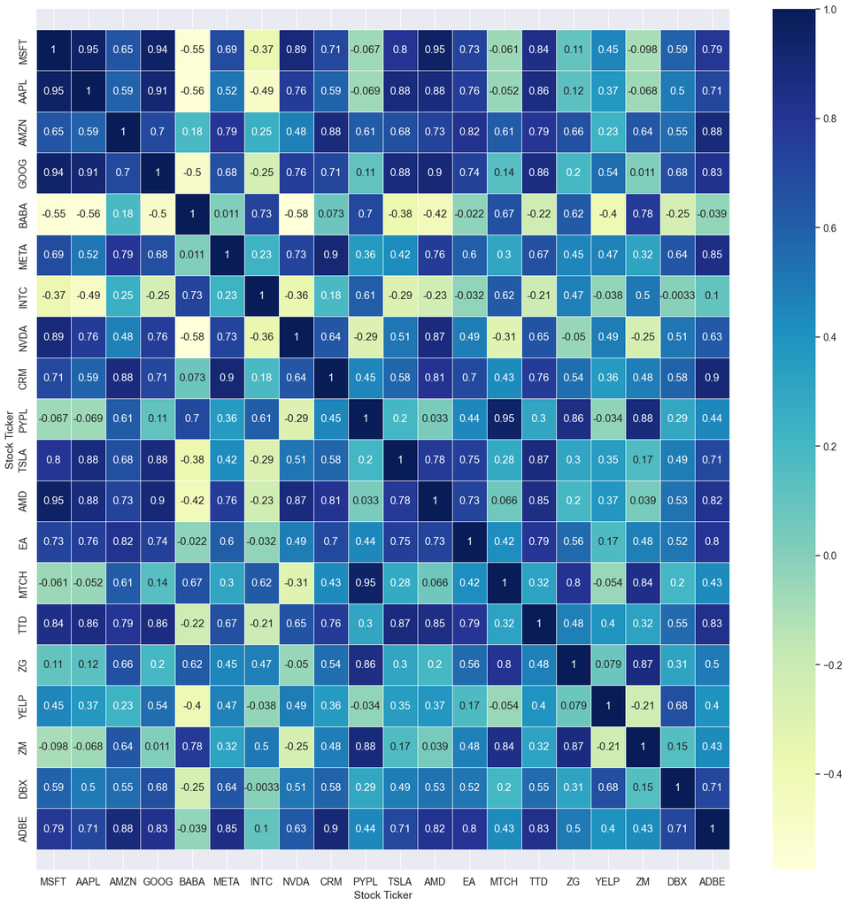

### Comparison in some "Tech-giant" stocks before and after layoffs

[interactive chart not shown]

### Predicting Stock Prices using LSTM model: Case study for AAPL stock

[interactive chart not shown]

```
Model: "sequential_5"
_________________________________________________________________
 Layer (type)                Output Shape              Param #
=================================================================
 lstm_15 (LSTM)              (None, 100, 50)           10400

 lstm_16 (LSTM)              (None, 100, 50)           20200

 lstm_17 (LSTM)              (None, 50)                20200

 dense_5 (Dense)             (None, 1)                 51

=================================================================
Total params: 50851 (198.64 KB)
Trainable params: 50851 (198.64 KB)
Non-trainable params: 0 (0.00 Byte)
_________________________________________________________________
```

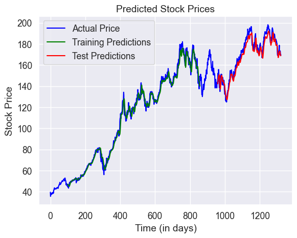

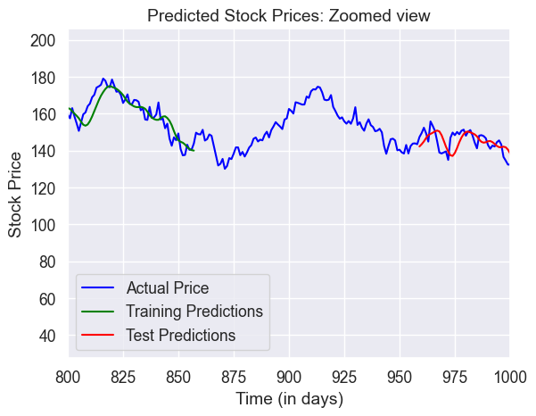